# Exploring bsem class

How to get information from the bsem package outcomes

Renato Panaro

2020-07-14

# Examples

This vignette describes how the package can be used to estimate artificial parameters. This is a former analysis in light of other studies based on replication such as Monte Carlo simulation study methods. There are two ways to specify a `sem` model:

1. the blocks, paths, exogenous, and the data set are not named by the user (internally named);
2. named list are passed to their respective arguments and consequently to the automated plot function.

## CFA

The implemented routines allow semi or full confirmatory factor analysis (CFA). Thus, at least one variable must be chosen to express each construct before running into the analysis. In other words, the user needs to specify at least one manifest variable that leads each block. In this way, semi-confirmatory FA assists the researcher in evidencing the possible structures to be tested in a conceptual (full) CFA later on. The function `bsem::simdata` is used to generate the simulated data. This routine internally produces artificial variances that are used to generate normally distributed errors. Factor scores (lambda) are generated from a standard normal distribution and the factor loadings (alpha) from a uniform distribution with support ranging from 0.5 to 2. The factor loading direction is generated using signals simulated from the `sample` function. A new artificial data set is produced with the command below:

```r
dt3 <- bsem::simdata(paths = NULL,
                     exogenous = NULL)
```

The `paths` and`exogenous` arguments must be defined as `NULL` to obtain a data set suitable for factor analysis. Now we can run `bsem::sem` to check whether the `bsem::sem` retrieve estimates close to the real values of the parameters.

- A list of blocks is always necessary to represent the manifest variables related to each construct of the outer model:

```r
dt3$blocks
```

```
## $F1
## [1] 1 2 3
##
## $F2
## [1] 4 5 6 7
##
## $F3
## [1]  8  9 10
##
## $F4
## [1] 11 12 13 14 15 16
##
## $F5
## [1] 17 18 19 20 21
```

- Descriptive statistics for the posterior factor loadings are showed in the result in `rstan` fashion (based on `rstan::monitor`):

```r
cfa <- bsem::sem(data = dt3$data,
                       blocks = dt3$blocks
                       )
```

```
## Warning: The largest R-hat is 1.75, indicating chains have not mixed.
## Running the chains for more iterations may help. See
## http://mc-stan.org/misc/warnings.html#r-hat
```

```
## Warning: Bulk Effective Samples Size (ESS) is too low, indicating posterior means and medians may be unreliable.
## Running the chains for more iterations may help. See
## http://mc-stan.org/misc/warnings.html#bulk-ess
```

```
## Warning: Tail Effective Samples Size (ESS) is too low, indicating posterior variances and tail quantiles may be unreliable.
## Running the chains for more iterations may help. See
## http://mc-stan.org/misc/warnings.html#tail-ess
```

```
##
## Extracting posterior samples, please wait...
##
## Done!
```

- The structural model can be easily viewed with the plotting routine `bsem::plot`:

[interactive chart not shown]

Moreover, we can compare the posterior factor loadings and the scores with the true values using the `bsem::arrayplot` function. For example:

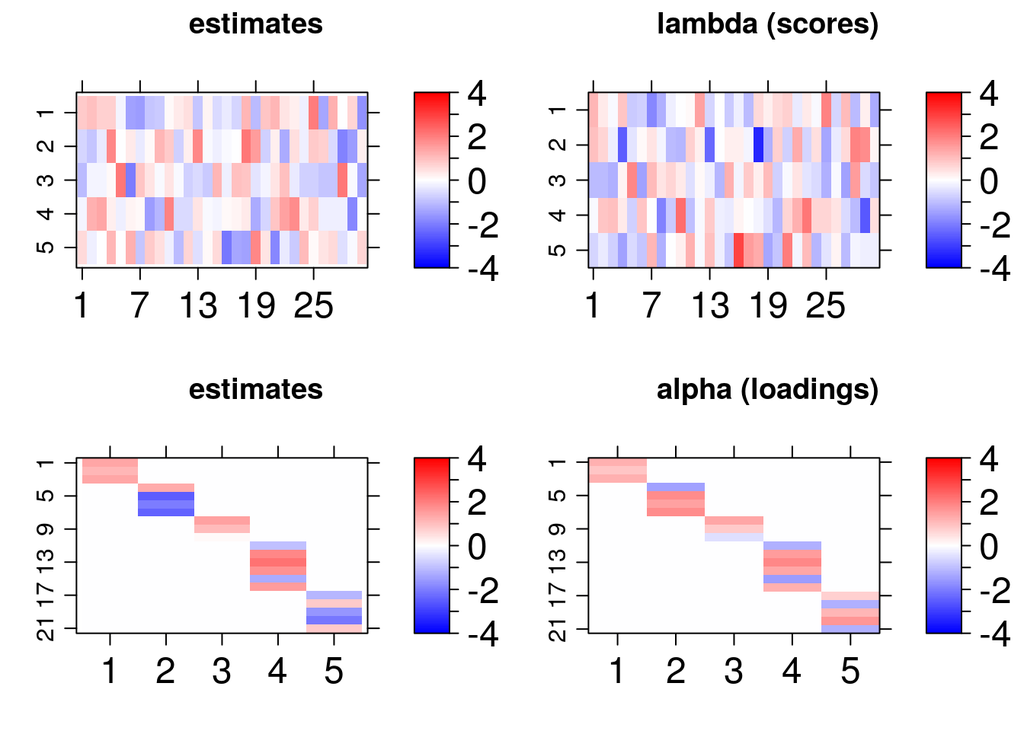

The `bsem::arrayplot` graphs show that the loadings and scores pattern was captured by the model. To get closer estimates it may be necessary to increase the number of iterations or the warmup period since this is a model with many parameters.

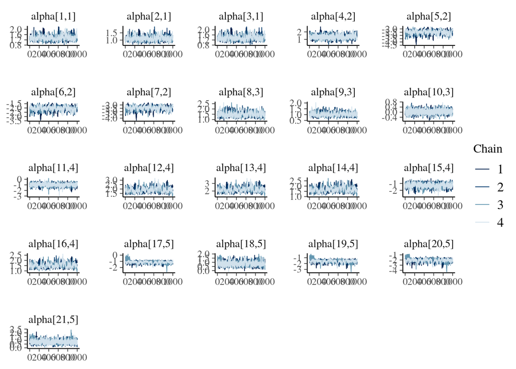

Remember each chain runs in a separate thread, thus, it is recommended specifying the number of cores at least equal to the number of chains. Indeed, from our experience, an increase in the number of iterations raises the runtime but considerably improves the interval and point estimates.

## SEM

For this model we will use the simulated data already described in the Get started vignette. This model includes variables that are explained by some common factors, those variables are referred to as the exogenous variables.

```r
dt <- bsem::simdata()
```

```r
sem <- bsem::sem(data = dt$data,
                       blocks = dt$blocks,
                       paths = dt$paths,
                       exogenous = dt$exogenous
                       )
```

```
##
## Extracting posterior samples, please wait...
##
## Done!
```

Similar outcomes can be also obtained for this model:

[interactive chart not shown]

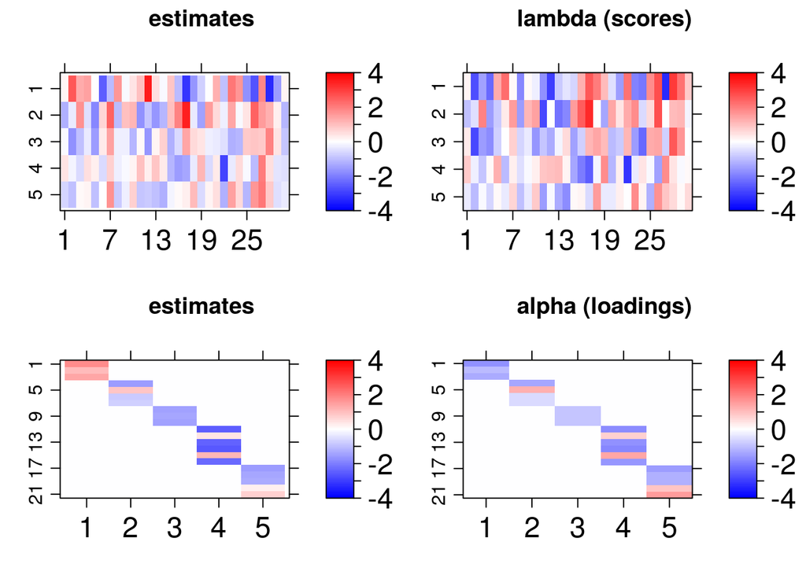

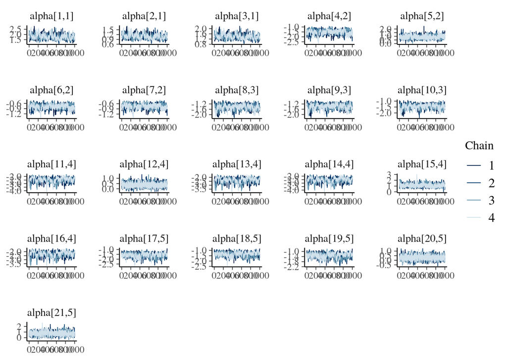

# Graphical posterior analysis

The first thing to do after fitting the model is to check posterior statistics to assess whether the estimates are good to describe the proposed CFA or SEM model.

## Interval estimate

Two types of intervals can be obtained:

### HPD interval

```r
names(cfa$credint)
```

```
## [1] "alpha"  "lambda" "sigma2"
```

- This data can be used to plot interval estimates using two packages, `ggplot2` and `tidybayes`:

```r
library("ggplot2")
library("tidybayes")
```

- `dt` data.frame object has the mean loadings and the HPD interval lower and upper limits (`ll` and `lu`):

```r
dt <- data.frame(
  li = cfa$credint$alpha[, 1],
  lu = cfa$credint$alpha[, 2],
  m = c(cfa$mean_alpha)
)
```

- `lnames` and `snames` are used to find the loadings of the conceptual model (those that might not equal zero).

```r
lnames <- rownames(cfa$mean_alpha)
snames <- rownames(cfa$mean_lambda)
```

- `find` help us finding these values:

```r
find <- paste0("alpha[", which(lnames %in% unlist(cfa$blocks)), ",", rep(1:length(cfa$blocks), lengths(cfa$blocks)), "]")

dt <- dt[find, ]
```

- One of the options to plot the loadings HPD intervals chart is:

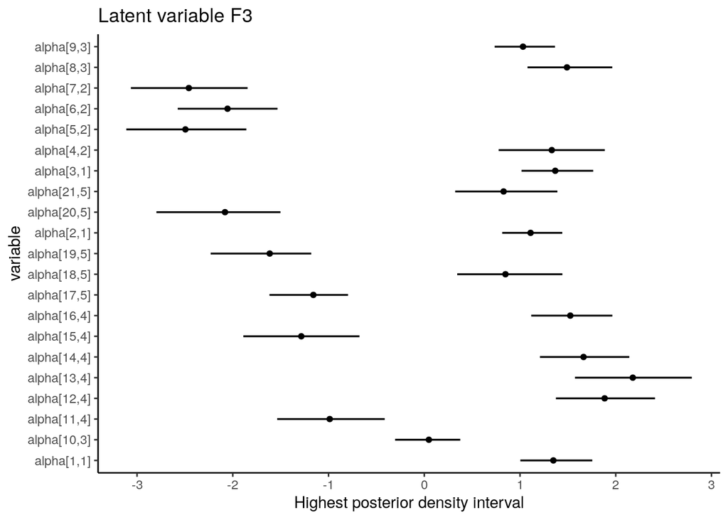

```r
ggplot(aes(y = find, x = m, xmin = li, xmax = lu), data = dt) +
  geom_pointintervalh() +
  theme_classic() +
  labs(
    title = paste("Latent variable", colnames(cfa$mean_alpha)[3]),
    x = "Highest posterior density interval",
    y = "variable"
  )
```

### Equal tails interval

Alternatively, it is possible to access equal tails credibility intevals using the `bayesplot` package:

```r
library("bayesplot")
```

- `find` help us finding the loading values that have been previously determined to estimate the latent scores:

```r
find <- paste0("alpha[", which(lnames %in% unlist(cfa$blocks)), ",", rep(1:length(cfa$blocks), lengths(cfa$blocks)), "]")

dt <- dt[find, ]
```

- The equal tails intervals are:

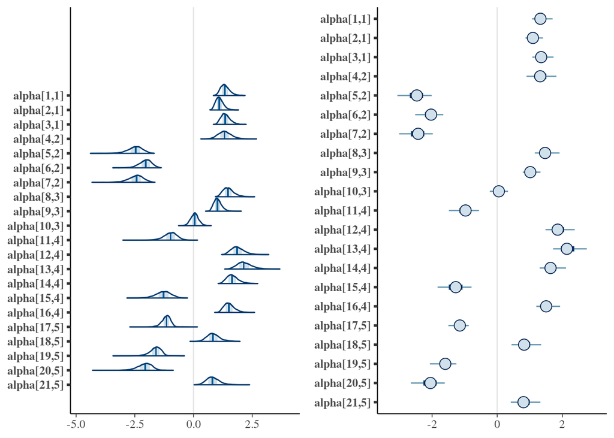

```r
gridExtra::grid.arrange(mcmc_areas(cfa$posterior$alpha[, , find]),
  mcmc_intervals(cfa$posterior$alpha[, , find]),
  layout_matrix = matrix(c(1, 1, 2, 2), ncol = 2)
)
```

In addition to the possibilities for intervals, other `mcmc_.` graphs are recommended, several options include histograms, violin plots, pair plots, and others.